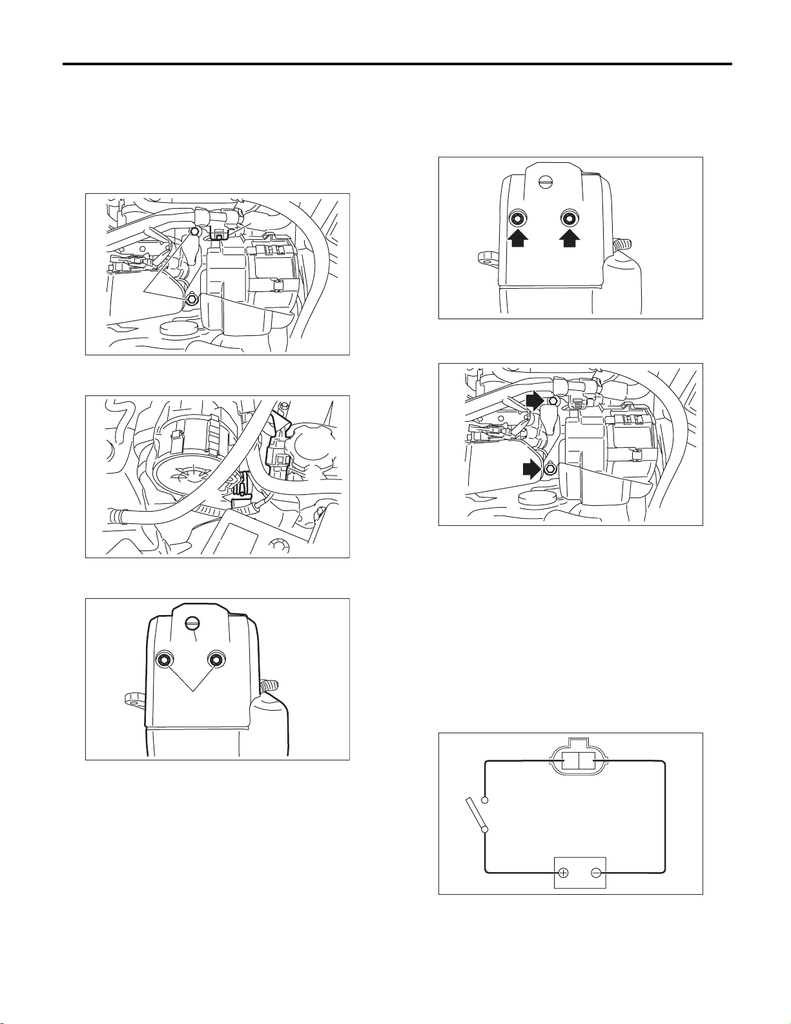

EC(STI)-53

Secondary Air Pump

EMISSION CONTROL (AUX. EMISSION CONTROL DEVICES)

12.Secondary Air Pump

A: REMOVAL

1) Disconnect the ground cable from battery.

2) Remove the clip (A) which holds the harness on

the harness stay and remove the bolt (B) which

holds the secondary air pump on the vehicle.

3) Disconnect the connector (A) and air duct (B)

from secondary air pump.

4) Remove the secondary air pump from the vehi-

cle and the resonator from the secondary air pump.

B: INSTALLATION

Install in the reverse order of removal.

Tightening torque:

6.4 N·m (0.7 kgf-m, 4.7 ft-lb)

Tightening torque:

19 N·m (1.9 kgf-m, 14.0 ft-lb)

C: INSPECTION

1. SECONDARY AIR PUMP

1) Check that the secondary air pump has no defor-

mation, cracks or other damages.

2) Connect battery positive terminal to the terminal

No. 2 and battery negative terminal to the terminal

No. 1, and inspect the secondary air pump opera-

tion.

CAUTION:

Do not operate the secondary air pump contin-

uously for 80 seconds or more.

2. OTHER INSPECTIONS

Check that the air duct or resonator has no cracks,

damage or loose part.

(A) Clip

(B) Bolt

(B)

(A)

(B)

(A)

(A)

(B)